# Session 07: Beyond party: social sorting and non-partisan identities

Tristan Muno

October 21, 2026

## Session 07 goals

By the end of today, you will be able to:

1. Define social sorting and explain why an aligned cleavage structure raises out-group animus.
2. Give a case in which the polarizing identity is not partisan at all, and say what makes it behave like one.
3. Assess how much support the evidence gives the claim that cross-cutting identities dampen animus.
4. Describe the four ways multiple group identities can be represented (intersection, dominance, compartmentalization, merger), and explain why a more complex social identity should lower out-group bias.

## Today

1. **Part 1: Groups beyond party**
   - From partisans to groups
   - Group exercise
   - Hobolt et al. (2020)
2. **Part 2: Many identities at once**
   - Group exercise
   - Social identity complexity (Roccas and Brewer 2002)
   - Harteveld (2021)
3. **Wrap-up**

## Where we are

- Session 04: AP as warmth toward **co-partisans** and dislike of **opposing partisans**
- Session 06: across 25 countries, party beat religion, class and nationality
- The block that starts today pushes on the concept

Is party special, or one group among many?

# Part 1: Groups beyond party

## Where AP started

> “the tendency of people identifying as Republicans or Democrats to view opposing partisans negatively and copartisans positively”

> Iyengar and Westwood (2015, 691)
- Two components: liking **us** and disliking **them**
- Both defined by **party**

## Not a partisan mechanism

Social identity theory asks for three steps (Tajfel and Turner 1986):

1. **Categorization**: us and them
2. **Identification**: I am one of us
3. **Comparison**: we are better than them

**Important**

**Generalised, AP is in-group liking and out-group dislike between social groups that politics divides.** Party is one such group. Religion, region, language or a referendum camp can be others.

## Group exercise

In groups of four, ten minutes.

1. Which **social divides** could show affective polarization?
   - Which are **general** across established democracies?
   - Which are **context specific**?
2. Your **home country**: what are the dominant (perceived) divides?
3. What makes group conflict **salient**? When does AP arise, and when does it stay low?

## Exchange

**General divides**

**Context specific divides**

**When does AP arise?**

# Hobolt, Leeper and Tilley (2020)

## Introduction

- Is affective polarization limited to **partisanship**?
- The 2016 EU referendum: Europe was a minor issue before it, under 10% in 2015
- No labels for the two sides **before** the campaign
- Can one event create identities that polarize like parties?

## Theory

**Opinion-based groups**: a shared opinion becomes the basis of a social identity. They form when people are compelled to take sides.

Table 1: The three components of affective polarization along opinion-based lines in Hobolt et al. (2020), and the evidence the paper uses for each.

| Component | What it means | Evidence used |
| --- | --- | --- |
| Identification | I see myself as a Leaver or a Remainer | Share with an identity, attachment scale |
| Differentiation | We are good, they are bad | Trait ratings, social distance |
| Evaluative bias | The identity colours judgement | Economic perceptions, conjoint choices |

## Research design

Table 2: The data behind Hobolt et al. (2020). All come from online quota panels weighted to the British population.

| Source | When | Used for |
| --- | --- | --- |
| British Election Study panel | 2016 to 2019, about 30,000 per wave | Prevalence and stability of identities |
| YouGov and Sky surveys | 2017 to 2019 | Attachment, traits, social distance, economy |
| Two YouGov conjoints | October 2017, about 1,650 each | Choosing a BBC director-general and a lodger |

- Every measure is taken for **party** and **Brexit** identity side by side
- The measures are familiar from sessions 4 to 6

## Results: identification

- About **75%** call themselves a Leaver or a Remainer, as many as hold a party identity
- Attachment slightly **stronger** than to a party: 3.4 against 2.9 to 3.0, on a 1 to 5 scale
- Stable from 2016 to 2019
- Only 35% of Leavers are Conservatives, only 36% of Remainers Labour

Brexit identities **cut across** party lines.

## Results: differentiation

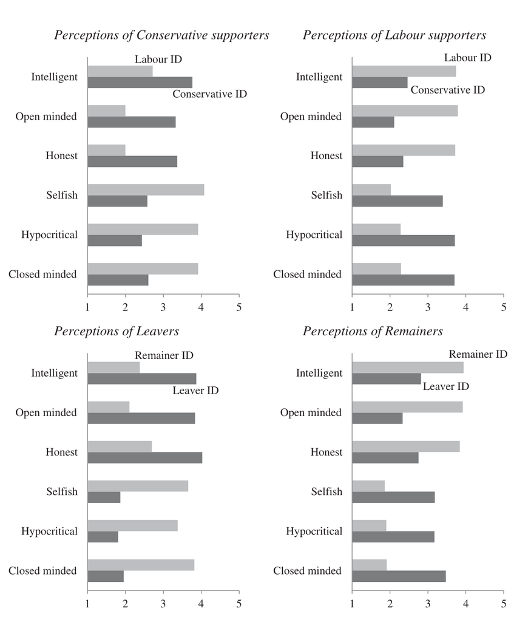

Figure 1: Mean agreement (1 to 5) that six traits describe Conservative and Labour supporters (top) and Leavers and Remainers (bottom), by the respondent’s own identity. Each side sees itself as intelligent and honest, and the other as selfish and closed minded, for Brexit as much as for party. *Source:* Hobolt et al. (2020), Figure 2.

Table 3: Share happy with a son- or daughter-in-law from the other side, YouGov, September 2017. *Source:* Hobolt et al. (2020), Table 3.

| Happy with a child marrying the other side |  |
| --- | --- |
| Conservatives | 24% |
| Labour | 19% |
| Leavers | 45% |
| Remainers | 30% |

- The **same** mirror image for party and Brexit

## Results: evaluative bias

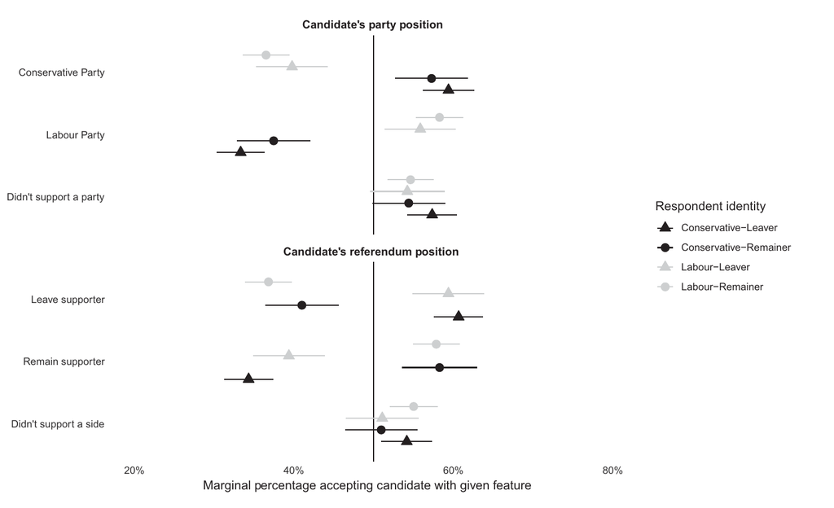

Figure 2: Share of times a candidate for BBC director-general with a given party or referendum position was chosen, for four combinations of party and Brexit identity. Each group prefers its own party, and, within party, its own Brexit side. *Source:* Hobolt et al. (2020), Figure 3.

- Economy, party held constant: Leavers **more** positive than Remainers, a larger gap than between the parties
- Conjoint: people pick their **own Brexit side** for BBC head and lodger
- Within each party, and slightly more than for party

## Conclusion

- AP can grow from a **non-partisan** identity, and fast
- A referendum is necessary, not sufficient
- The authors’ guess: Brexit **cut across** the party divide
- Open: will it fade, or will the parties realign around it?

Is a referendum camp a social group, or just a strong opinion?

# Part 2: Many identities at once

## Several groups at once

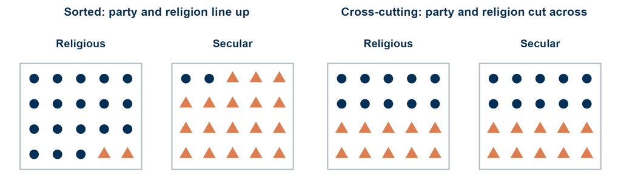

Figure 3: Two parties, circles and triangles, in a population split by religion. When the divides line up (left), knowing a person’s party tells you their religion. When they cut across (right), it tells you nothing.

## Group exercise

In groups of four, eight minutes.

1. In what ways can multiple group identities **relate** to each other?
2. How might different constellations shape **affective polarization**?
3. Which constellations **increase** AP, and which **decrease** it?

## Exchange

**How identities can relate**

**More AP, or less?**

# Social identity complexity

## Social identity complexity

**Social identity complexity**: how a person sees the overlap among their own in-groups (Roccas and Brewer 2002).

- **Objective** overlap is not the same as **perceived** overlap
  - Many Italians are not Catholic, but some people think “real” Italians are
- Two signs of low complexity:
  - My groups contain the **same people**
  - My groups share the **same traits** and values

## Four structures

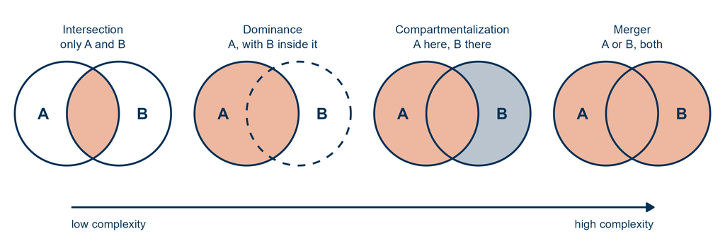

Figure 4: Four ways to represent two in-groups, A and B, with the in-group shaded. Intersection keeps only those in both, dominance keeps A and treats B as a feature of it, compartmentalization switches between A and B by context, and merger includes everyone in either. Complexity rises from left to right. Drawn after Roccas and Brewer (2002), Figure 1.

[output not shown]

Complexity means seeing that one’s groups differ **and** reconciling them (Roccas and Brewer 2002, after Tetlock).

## Why complexity helps

- Someone who is “them” on one line is **“us”** on another
- No single group has to carry all of one’s belonging
- Disliking a group that contains friends feels **inconsistent**
- Complexity is lower under **stress** and **threat**, and where groups overlap in society
- First evidence: student surveys in the US and Israel, higher complexity goes with more **tolerance**, correlation only

## From person to society

1. Divides **line up** in society (social sorting)
2. People see their in-groups as **one** (low complexity)
3. Out-groups look homogeneous and different in every way
4. More **affective polarization**

Shown for the US (Mason 2016). Does it travel?

# Harteveld (2021)

## Introduction

- Does AP rise when political divides **align** with non-political ones?
- AP varies widely between countries and over time
- A classic idea: **cross-cutting** cleavages calm conflict
- So far tested in the US: does it hold around the world?

## Theory

Two mechanisms:

1. **Infusion**: political groups take on the tensions of the social groups they line up with
2. **Complexity**: aligned identities make the out-group look homogeneous (Roccas and Brewer 2002)

**Note**

**Hypothesis: higher levels of social sorting along political lines are associated with higher levels of affective polarization.** The author is explicit that the arrow could also point the other way.

## Research design

Table 4: The two studies of Harteveld (2021). Study 1 looks for the pattern across societies, Study 2 looks for it within persons.

|  | Study 1 | Study 2 |
| --- | --- | --- |
| Data | CSES, harmonized election surveys | LISS, Dutch online panel |
| Unit | Country and election | Person and year |
| Scope | 119 elections, 40 countries, 1996 to 2018 | 8,205 people, 2008 to 2018 |
| Asks | Do more sorted elections show more AP? | Do people who fit their party better show more AP? |

## Measuring the concepts

**Social sorting** (Study 1): how well party identification can be predicted from income, education, region and religion.

- **Cramér’s V**: an association between two categorical variables, from 0 (none) to 1 (perfect)
- Social Sorting Score = the average of the four V’s

**Affective polarization**: Reiljan’s index for countries, Wagner’s weighted score for persons (Reiljan 2020; Wagner 2021).

**Warning**

**These are ascribed categories, not felt identities.** Being in the lowest income fifth is not the same as identifying as working class.

## Two ways to compare

- **Between** countries: are more sorted countries more polarized?
  - Countries differ in many other stable ways: culture, history, institutions
- **Within** countries, with **fixed effects**: in elections where a country is more sorted than usual, is AP higher too?
  - Every stable feature of a country cancels out
- **Controls**: ideological polarization, issue salience, number of parties
- **Standardized** coefficient: effect in standard deviations, comparable across variables

## Results: Study 1

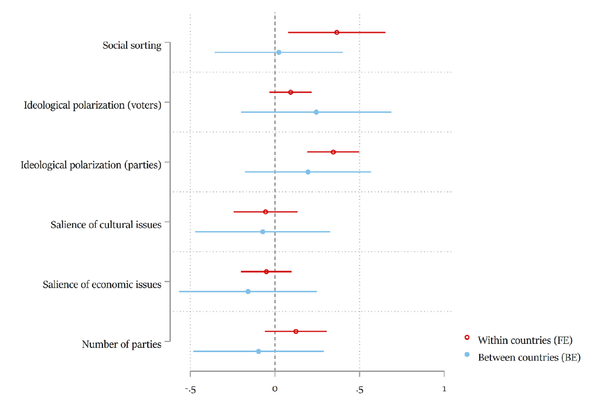

Figure 5: Standardized effects on the Affective Polarization Index, 119 elections in 40 countries, with 95% intervals. Within countries (red), more social sorting goes with more AP, about as strongly as party polarization. Between countries (blue), there is no relation. *Source:* Harteveld (2021), Figure 1.

- Within: **+0.37 SD** of AP per SD of sorting
- Between: **no** relation
- As large as party ideological polarization
- Several alignments matter more than one
- Region and religion strongest

## Study 2: fit to one’s party

- **Panel**: the same people, asked again each year
- Sorting for a person: how well age, education, income and urbanity **predict** their party
  - A small prediction error: you fit the profile of your party
- **Hybrid model**: two effects at once
  - **Within** persons: when you fit your party better than usual, is your AP higher?
  - **Between** persons: are people who fit better in general more polarized?

## Results: Study 2

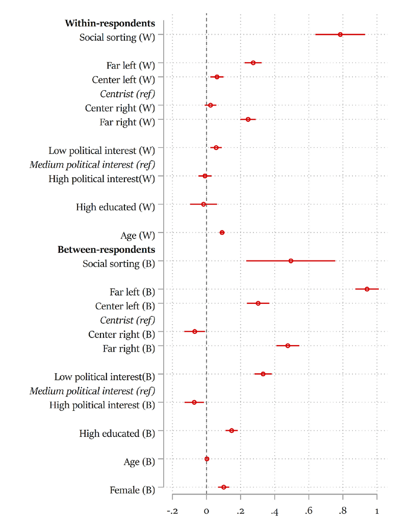

Figure 6: Effects on a person’s weighted affective polarization in the Dutch LISS panel, 2008 to 2018, with 95% intervals. W marks effects within persons over time, B effects between persons. Fitting one’s party better goes with more AP in both. *Source:* Harteveld (2021), Figure 3.

- When people come to fit their party **better**, they become **more** polarized
- People who fit better are more polarized in general too
- Even in the Netherlands, a low AP country

## Conclusion

- Sorting goes with more AP **within** countries and **within** persons
- AP is not purely political: reforming politics alone may not lower it
- Limits: observational, the arrow may run both ways, ascribed categories

How would you design the conjoint the author proposes, a Green supporter who is lower or higher educated?

# Wrap-up

## Recap: takeaways

- AP is in-group liking and out-group dislike between **groups**, and party is one of them
- A referendum created Leave and Remain identities that polarize as much as parties
- What matters is also how identities **overlap**: aligned or cross-cutting
- Complex identities should lower bias, and sorting goes with more AP within countries and persons

## Recap: learning goals

**Goal 1. Social sorting**

- Political divides line up with non-political ones, so the other side differs in every way and looks like one block

**Goal 2. A non-partisan case**

- Leave and Remain: identification, differentiation and evaluative bias, as for parties

**Goal 3. Evidence on cross-cutting identities**

- Consistent correlations within countries and persons, no causal design, and Brexit polarized although it cut across party

**Goal 4. Social identity complexity**

- Intersection, dominance, compartmentalization, merger: the more inclusive, the less bias

## Next session

- **Session 08: Is partisanship a social identity, or a cue about ideology?**
- Today we read AP as group identity. Next: is it policy disagreement in disguise?
- Core reading: Orr et al. (2023) and Dias and Lelkes (2022)

## References

Dias, Nicholas, and Yphtach Lelkes. 2022. “The Nature of Affective Polarization: Disentangling Policy Disagreement from Partisan Identity.” *American Journal of Political Science* 66 (3): 775–90. https://doi.org/10.1111/ajps.12628.

Harteveld, Eelco. 2021. “Ticking All the Boxes? A Comparative Study of Social Sorting and Affective Polarization.” *Electoral Studies* 72: 102337. https://doi.org/10.1016/j.electstud.2021.102337.

Hobolt, Sara B., Thomas J. Leeper, and James Tilley. 2020. “Divided by the Vote: Affective Polarization in the Wake of the Brexit Referendum.” *British Journal of Political Science* 51 (4): 1476–93. https://doi.org/10.1017/S0007123420000125.

Iyengar, Shanto, and Sean J. Westwood. 2015. “Fear and Loathing Across Party Lines: New Evidence on Group Polarization.” *American Journal of Political Science* 59 (3): 690–707. https://doi.org/10.1111/ajps.12152.

Mason, Lilliana. 2016. “A Cross-Cutting Calm: How Social Sorting Drives Affective Polarization.” *Public Opinion Quarterly* 80 (S1): 351–77. https://doi.org/10.1093/poq/nfw001.

Orr, Lilla V., Anthony Fowler, and Gregory A. Huber. 2023. “Is Affective Polarization Driven by Identity, Loyalty, or Substance?” *American Journal of Political Science* 67 (4): 948–62. https://doi.org/10.1111/ajps.12796.

Reiljan, Andres. 2020. “‘Fear and Loathing Across Party Lines’(also) in Europe: Affective Polarisation in European Party Systems.” *European Journal of Political Research* 59 (2): 376–96. https://doi.org/10.1111/1475-6765.12351.

Roccas, Sonia, and Marilynn B. Brewer. 2002. “Social Identity Complexity.” *Personality and Social Psychology Review* 6 (2): 88–106. https://doi.org/10.1207/S15327957PSPR0602_01.

Tajfel, Henri, and John C. Turner. 1986. “The Social Identity Theory of Intergroup Behavior.” In *Psychology of Intergroup Relation*, 2nd ed., edited by Stephen Worchel and William G. Austin. Nelson Hall.

Wagner, Markus. 2021. “Affective Polarization in Multiparty Systems.” *Electoral Studies* 69: 102199. https://doi.org/10.1016/j.electstud.2020.102199.